# Clase2_py

## Curso de introducción a la programación con Python

**Autor: Luis Fernando Apáez Álvarez**  
-Curso PyM-  
Clase 2: Bucles y condicionales  
Fecha: 09 de Agosto del 2022

### Contenido

Algo de Lógica

Condicionales

Bucle for

Bucle while

### Introducción

En esta clase veremos el concepto de *condicional* en **Python**, el cual nos permitirá realizar una accíon si cierta condición es verdadera, en otras palabras si cierta variable boolena posee el valor de `True`; y se relizará también una acción en dado caso de que la variable boleana tenga el valor de `False`.

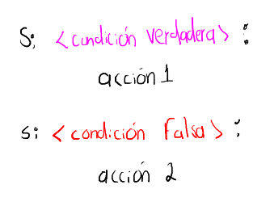

Asimismo, veremos también el concepto de *bucles*, en el cual cierta acción o acciones serán ejecutadas repetidamente cierto número de veces o hasta que cierta condición se cumpla.

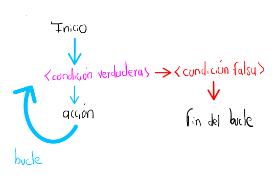

### Algo de lógica

Para entender de mejor manera el concepto de *condicional* (y muchos otros conceptos) es preciso tener ciertos conocimientos sobre **Lógica**. Recordemos que la clase pasada vimos algunos operadores lógicos y experimentamos con ellos cambiando el valor de verdad de una variable. Por ejemplo, si consideramas

```python
v1 = False
print(v1)

print("-" * 30)

# Podemos cambiar su valor a True mediante el operador de negacion
v1 = not v1
print(v1)
```

```
False
------------------------------
True
```

De manera similar, el resto de operadores poseían un valor de verdad dependiendo las variables booleanas que las involucraban. Por ejemplo

```python
# Declaramos dos variables boolenas
v2 = False
v3 = True

# Entonces
v4 = v2 and v3
print(f"La variable v4 es: {v4}")

print("-" * 30)

v5 = v2 or v3
print(f"La variable v4 es: {v5}")
```

```
La variable v4 es: False
------------------------------
La variable v4 es: True
```

Pues:

- Para el operador `and`: éste es verdadero solamente cuando todas las variables booleanas involucradas son verdaderas; y será falso cuando al menos una de las variables involucradas sea falsa.
- Para el operador `or`: éste es verdadero siempre que, al menos una de las variables involucradas sea verdadera; será falso solamente cuando todas las variables involucradas sean falsas.
- Para el operador `not`: éste es verdadero solo si la variable involucrada es falsa, y viceversa.

### Condicionales

Retomando la idea del inicio de la clase, básicamente un condiconal representa ciertas instrucciones a ejecutar si una condición se cumple o es verdadera, asimismo, ciertas isntrucciones serán ejecutadas cuando la condición sea falsa. Por ejemplo

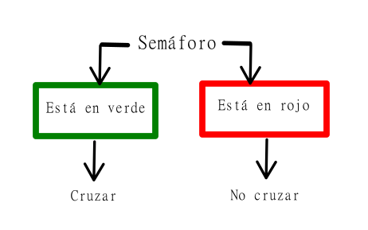

donde, **si** está en verde, **entonces** cruzamos, **si no** entonces no cruzamos. Así, para menjar condicionales dentro de **Python** manejamos la siguiente estructura:

```
if <<condicion>>:
    instrucciones en caso de que la condicion sea verdadera
else:
    instrucciones en caso de que la condicion sea falsa
```

Es importante mencionar que en **Python** la sangría tiene un papel importante, pues notemos que en la línea referente a las instrucciones se ha implementando un sangrado respecto a las palabras `if` y `else`. Por ejemplo, si escribimos el código anterior pero sin el sangrado en las líneas de las instrucciones

```
if <<condicion>>:
instrucciones en caso de que la condicion sea verdadera
else:
instrucciones en caso de que la condicion sea falsa
```

obtendríamos un error de identación. Ahora bien, podemos implementar nuestro primer condicional utilizando el ejemplo del semáforo:

```python
# declaramos una variable denominada semaforo
# y le asignamos una cadena de texto representando
# el color que queramos que tenga
print("¿Cuál es el color que actualmente señala el semáforo?")
semaforo = input()

print("-" * 30)
# inicio del if
if semaforo == "verde":
    # instruccion a realizar si la condicion del if es
    # verdadera
    print("Cruce")
# caso en semaforo no sea igual a "verde"
else:
    # instruccion a realizar si la condicion del if
    # es falsa
    print("No cruce")
```

[output not shown]

Donde, una vez que ingresamos el color a la variable semáforo, si ocurre que la cadena asignada a dicha variable es igual a la cadena `verde`, entonces se imprimirá el mensaje `Cruce`. Si la condición dada en el `if` no se cumple, es decir, si la cadena asignada a la variable `semaforo` no es igual a la cadena `verde`, entonces se imprimirá `No cruce`. Cabe resaltar que el `else` del condicional `if` es opcional, es decir, si así lo queremos o si así nos sirve, simplemente podemos declarar el condicional `if` sin el `else`. Por ejemplo

```python
# Le pedimos al usuario que ingrese su edad
print("Por favor, introduzca su edad: ")
edad = int(input())

# Primera validacion
if edad >= 18:
    print("Eres mayor de edad")

# Si la condicion del if anterior es falsa, entonces
# no se ejecutara nada. Puede decirse entonces que
# dicha instrucción será ignorada por Python, luego,
# se ejecutara lo que haya debajo de ese codigo, que en
# este caso es:

# Segunda validacion
if (edad < 18) and (edad >= 14):
    print("Eres un estudiante de preparatoria")

# Tercera validacion
if (edad < 14) and (edad >= 4):
    print("Eres un estudiante niño/a")

# cuarta validacion
if (edad < 4) and (edad >= 0):
    print("Eres un estudiante bebe")
```

```
Por favor, introduzca su edad:
24
Eres mayor de edad
```

Otro ejemplo. Supongamos que queremos escribir un programa que realice un descuento en automático del 20% si el monto total de la venta es mayor a 5000; si el monto total de la venta está entre 2000 y los 5000, entonces el descuento será del 10%. Finalmente, para montos de venta menores a los 2000 el descuento será del 5%. Recordemos que, si tenemos, por ejemplo, que un producto vale 1000, si éste tiene un descuento del 10% entonces para calcular el costo después del descuento de dicho producto tenemos que: $$ \textrm{Costo final: } 1000 - 1000 * 0.1 = 900 $$

Lo anterior lo implementamos en **Python** como sigue:

```python
# variable que almacene el monto de venta
print("Ingrese el monto total de la venta: ")
monto = float(input())

print("-" * 30)

# declaramos una variable auxiliar para calcular el monto final
# despues del descuento. Por el momento le asignamos el valor de 0
monto_final = 0

# implementamos el if
# monto mayor o igual a 5000
if monto >= 5000:
    monto_final = monto - monto * 0.2

# monto mayor o igual a 2000 y menor a 5000
if (monto >= 2000) and (monto < 5000):
    monto_final = monto - monto * 0.1

# cualquier otro caso (montos menores a 2000)
else:
    monto_final = monto - monto * 0.05

# Mensaje final al usuario
print(f"El monto total a pagar es de ${monto_final}")
```

```
Ingrese el monto total de la venta:
3580
------------------------------
El monto total a pagar es de $3222.0
```

### Elif

Cuando es necesario que ocupemos varias instrucciones `if`, o en otras palabras cuando haya muchos casos que considerar para un `if` (como en el ejemplo anterior), una alternativa más amigable es utilizar la cláusula `elif`, la cual se puede interpretar como: *si no se cumple la condición anterior, y si...*

En código tenemos

```python
# variable que almacene el monto de venta
print("Ingrese el monto total de la venta: ")
monto = float(input())

print("-" * 30)

# declaramos una variable auxiliar para calcular el monto final
# despues del descuento. Por el momento le asignamos el valor de 0
monto_final = 0

# implementamos el if
# monto mayor o igual a 5000
if monto >= 5000:
    monto_final = monto - monto * 0.2

# monto mayor o igual a 2000 y menor a 5000
elif (monto >= 2000) and (monto < 5000):
    monto_final = monto - monto * 0.1

# cualquier otro caso (montos menores a 2000)
else:
    monto_final = monto - monto * 0.05

# Mensaje final al usuario
print(f"El monto total a pagar es de ${monto_final}")
```

La ventaja es que considerar `if` y `elif` trae consigo la agrupación de todo el código involucrado, y no deja aislados los `if` como vimos al principio. De esta manera tenemos mayor exactitud en cuanto a las condiciones o casos que estamos manejando.

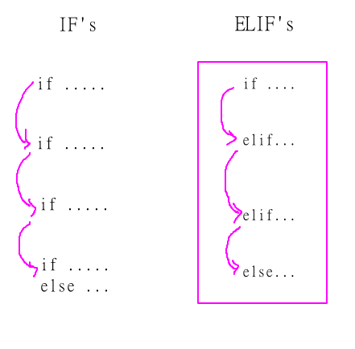

### Bucle for

Un *bucle* es un concepto, dentro de la programación, en el cual se estarán repitiendo algunas instrucciones cierto número de veces, o mientras una condición sea verdadera. En particular, el *bucle for* corresponde a la repetición de instrucciones **un determinado número de veces**. Por ejemplo, podemos programar lo siguiente:

- *imprime "Hola" cinco veces*

o equivalantemente:

- *ejecuta* `print("Hola")` *cinco veces*

donde en esta última equivalencia vemos que una instrucción se está repitiendo (entrando en bucle) un número especifico de veces.

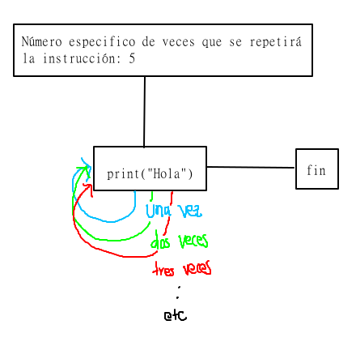

donde el bucle `for` terminará una vez que la instrucción haya sido ejecutada 5 veces. Lo anterior lo implementamos en código como:

```python
# comienzo del bucle for
# range(5) genera el rango 0,1,2,3,4
# range(8) genera: 0,1,2,3,4,5,6,7
# nunca se incluye el valor dado como parametro en la
# funcion range()
for i in range(5):
    # instruccion a ejecutar
    print("Hola")
```

```
Hola
Hola
Hola
Hola
Hola
```

donde `i in range(5)` significa que la variable `i` tomara **cada uno** de los valores generados en el rango de **números enteros** 0-4 (es decir 0,1,2,3,4). Así, cuando la `i` ya tomó todos los valores del rango del bucle, entonces dicho bucle finaliza.

De tal manera, podemos ver, digamos, con rayos x cómo funciona el ciclo `for` anterior:

- Para `i=0`: se ejecuta la instrucción `print("Hola")`
- Para `i=1`: se ejecuta la instrucción `print("Hola")`
- Para `i=2`: se ejecuta la instrucción `print("Hola")`
- Para `i=3`: se ejecuta la instrucción `print("Hola")`
- Para `i=4`: se ejecuta la instrucción `print("Hola")`

es por ello que se imprime 5 veces la cadena `"Hola"`. Cabe resaltar que en este caso, la variable `i` no fue definida previamente como estamos acostumbrados pues, dicha variable `i`, pertenece **exclusivamente al bucle**, esto es, dicha variable se crea al momento de ejecutar el bucle, y ésta se elimina una vez que el bucle finaliza.

Podemos ver más a detalle cómo es que la variable `i` cambia y va tomando todos los valores que genera cierto rango (de números enteros):

```python
# range(3): 0,1,2
for i in range(3):
    # imprimimos el valor de i
    print(i)
```

```
0
1
2
```

Donde:

- Para `i=0`: se ejecuta la instrucción `print(i)`, pero como en esa iteración `i` tiene el valor de cero, por ello se imprime el 0.
- Para `i=1`: se ejecuta la instrucción `print(i)`, pero como en esa iteración `i` tiene el valor de uno, por ello se imprime el 1.
- Para `i=2`: se ejecuta la instrucción `print(i)`, pero como en esa iteración `i` tiene el valor de dos, por ello se imprime el 2.

Podemos jugar un poco con los bucles `for`:

```python
# range(3): 0,1,2,3,4
for i in range(5):
    # imprimimos el valor de i ** 2
    print(i ** 2)
```

```
0
1
4
9
16
```

O podemos ser un poco más específicos

```python
# range(3): 0,1,2,3,4,5,6
for i in range(7):
    # imprimimos el valor de i ** 2
    print(f"El número {i} elevado al cuadrado da como resultado: {i ** 2}")
```

```
El número 0 elevado al cuadrado da como resultado: 0
El número 1 elevado al cuadrado da como resultado: 1
El número 2 elevado al cuadrado da como resultado: 4
El número 3 elevado al cuadrado da como resultado: 9
El número 4 elevado al cuadrado da como resultado: 16
El número 5 elevado al cuadrado da como resultado: 25
El número 6 elevado al cuadrado da como resultado: 36
```

Asimismo, podemos especificar el inicio del rango y el final (menos 1). Por ejemplo, `range(2,6)` generará el rango de números enteros 2,3,4,5, donde no se incluye el 6; o `range(-1,3)` el cual generará el rango -1,0,1,2. En código

```python
for i in range(-1,3):
    print(i)
```

```
-1
0
1
2
```

Notemos que la salida como las anteriores del bucle `for`, no nos convienen en el sentido del espacio, por ejemplo para rangos grandes

```python
for i in range(20):
    print(i)
```

```
0
1
2
3
4
5
6
7
8
9
10
11
12
13
14
15
16
17
18
19
```

Una alternativa es cambiar la forma en que se están imprimiendo los resultados. Para ello utilizaremos el parámetro adicional `end` dentro de la función `print()`. Con este parámetro logramos que la impresión sea horizontal y no vertical. Por ejemplo, podemos pasar de

```python
print("Hola")
print("Mundo")
```

```
Hola
Mundo
```

a lo siguiente:

```python
print("Hola", end="-")
print("Mundo", end="-")
```

```
Hola-Mundo-
```

donde al colocar `end="-"`, además de especificar que la salida será horizontal, estamos especificando que después de cada impresión se colocará el caracter `-`. Podemos utilizar el "caracter vacío" `""` para que al final no se coloque nada

```python
print("Hola", end="")
print("Mundo", end="")
```

```
HolaMundo
```

pero ahora nuestro texto está junto. Para solucionar lo anterior implementamos espacios en blanco

```python
print("Hola", " ", end="")
print("Mundo", " ", end="")
```

```
Hola  Mundo
```

Así, gracias a lo anterior podemso escribir:

```python
for i in range(20):
    print(i, " ", end = "")
```

```
0  1  2  3  4  5  6  7  8  9  10  11  12  13  14  15  16  17  18  19
```

Otro ejemplo es que podemos calcular de maenra automática una tabla de multiplicar, por ejemplo

```python
# le pedimos al usuario que ingrese un numero para
# poder calcularle su tabla de multiplicar
# \ nos permite continuar escribiendo una cadena
# de texto larga en la siguiente linea
print("Ingrese un número del cual desea conocer \
su tabla de multiplicar")

num = int(input())
```

```
Ingrese un número del cual desea conocer su tabla de multiplicar
5
```

Después, lo que haremos será mostrar repetidamente el mensaje:

```python
print(f"{num} x {1} = {num * 1}")
print(f"{num} x {2} = {num * 2}")
```

```
5 x 1 = 5
5 x 2 = 10
```

pero iremos cambiando dicho 1 por el 2, el 3 y así sucesivamente hasta llegar al 10, lo cual conseguiremos implementanod un bucle `for` como sigue:

```python
# range(1,11): 1,2,3,...,10
for i in range(1,11):
    # cambiamos el numero fijo por la i
    print(f"{num} x {i} = {num * i}")
```

```
5 x 1 = 5
5 x 2 = 10
5 x 3 = 15
5 x 4 = 20
5 x 5 = 25
5 x 6 = 30
5 x 7 = 35
5 x 8 = 40
5 x 9 = 45
5 x 10 = 50
```

De tal manera, así es como conseguimos la tabla del 5. Otro ejemplo:

```python
print("Ingrese un número del cual desea conocer \
su tabla de multiplicar")

# entrada del usuario
num = int(input())
print("-" * 20)

# range(1,11): 1,2,3,...,10
for i in range(1,11):
    # cambiamos el numero fijo por la i
    print(f"{num} x {i} = {num * i}")
```

```
Ingrese un número del cual desea conocer su tabla de multiplicar
7
--------------------
7 x 1 = 7
7 x 2 = 14
7 x 3 = 21
7 x 4 = 28
7 x 5 = 35
7 x 6 = 42
7 x 7 = 49
7 x 8 = 56
7 x 9 = 63
7 x 10 = 70
```

### Bucle for dentro de otro bucle for

Podemos utilizar un bucle `for` dentro de otro bucle `for`, para ello podemos escribir algo como

```python
# i sera el nombre de la variable del primer for
for i in range(3):
    # j es el nombre de la variable del segundo for
    for j in range(4):
        print(f"{i} --> {j}")
```

```
0 --> 0
0 --> 1
0 --> 2
0 --> 3
1 --> 0
1 --> 1
1 --> 2
1 --> 3
2 --> 0
2 --> 1
2 --> 2
2 --> 3
```

En rayos x veríamos:

- Primera iteración del **primer for**: `i=0`:
  - Primera iteración del **segundo for**: `j=0`: De tal manera, en esta ejecución se imprimirá `0 --> 0`
  - Segunda iteración del **segundo for**: `j=1`: De tal manera, en esta ejecución se imprimirá `0 --> 1`
  - Tercera iteración del **segundo for**: `j=2`: De tal manera, en esta ejecución se imprimirá `0 --> 2`
  - Cuarta iteración del **segundo for**: `j=3`: De tal manera, en esta ejecución se imprimirá `0 --> 3`. Con este valor el **segundo bucle for** ha llegado a su fin, de tal manera, la primer ejecución del **primer bucle for** también ha finalizado. Se continua entonces con la segunda ejecución del **primer bucle for**.
- Segunda iteración del **primer for**: `i=1`:
  - Primera iteración del **segundo for**: `j=0`: De tal manera, en esta ejecución se imprimirá `1 --> 0`
  - Segunda iteración del **segundo for**: `j=1`: De tal manera, en esta ejecución se imprimirá `1 --> 1`
  - Tercera iteración del **segundo for**: `j=2`: De tal manera, en esta ejecución se imprimirá `1 --> 2`
  - Cuarta iteración del **segundo for**: `j=3`: De tal manera, en esta ejecución se imprimirá `1 --> 3`.
- Tercer iteración del **primer for**: `i=2`:
  - Primera iteración del **segundo for**: `j=0`: De tal manera, en esta ejecución se imprimirá `2 --> 0`
  - Segunda iteración del **segundo for**: `j=1`: De tal manera, en esta ejecución se imprimirá `2 --> 1`
  - Tercera iteración del **segundo for**: `j=2`: De tal manera, en esta ejecución se imprimirá `2 --> 2`
  - Cuarta iteración del **segundo for**: `j=3`: De tal manera, en esta ejecución se imprimirá `2 --> 3`.

Con lo cual conseguimos el resultado que vimos antes en la celda de código.

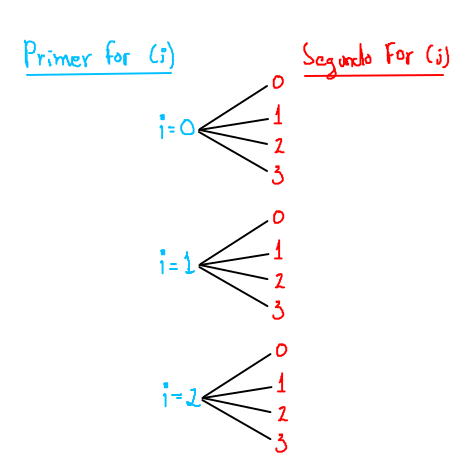

### Bucle while

En el caso del bucle `while`, éste es un bucle que se ejecutará siempre y cuando una cierta condición continúe siendo verdadera

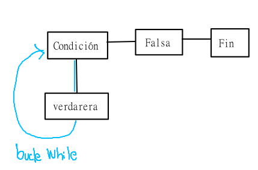

y dicho bucle parará sólo cuando la condición sea falsa. La estructura básica del bucle `while` es:

```
while <<condicion verdadera>>:
    instruccion a realizar mientras
    la condicion sea verdadera
```

Por ejemplo, podemos ejecutar `print("Hola")` **mientras** que una variable `x` sea mayor o igual a 0

```
# declaramos la variable x inicializandola en 4
x = 4
# declaramos el bucle while
while x >= 0:
    print("Hola")
    # Una vez que se ha impreso la cadena "hola"
    # el bucle while vuelve a evaluar la veracidad
    # de la condicion
```

El bucle anterior es un bucle infinito pues, como declaramos que `x` tiene el valor de 4 y en ningún momento hemos cambiado este valor de `x`, entonces `x` continuará valiendo 4, de tal manera, como 4 **siempre** es mayor o igual a cero, el bucle anterior será un bucle infinito, pues la condición del `while` **siempre** será verdadera.

Por ello, es común escribir dentro de nuestro bucle `while` alguna instrucción para que, en cierto momento, la condición dada sea falsa. Por ejemplo, en el código anterio podemos restar una unidad al valor de la `x` cada que se ejecute una iteración del bucle:

```python
# declaramos la variable x inicializandola en 4
x = 4
# declaramos el bucle while
while x >= 0:
    print("Hola")
    # Restamos una unidad al valor actual de la x
    x -= 1
```

```
Hola
Hola
Hola
Hola
Hola
```

Podemos ver lo anterior en rayos x:

- Primera validación de la condición: se válida si `x >= 0`, como `x` tiene el valor de 4, entonces la condición del `while` es verdadera, así, se ejecuta entonces la instrucción `print("Hola")`. Después, se ejecuta la instrucción `x -= 1` con lo cual cambiamos el valor de la `x` de 4 a 3.
- Segunda validación de la condición: se válida si `x >= 0`, como `x` tiene el valor de 3, entonces la condición del `while` es verdadera, así, se ejecuta entonces la instrucción `print("Hola")`. Después, se ejecuta la instrucción `x -= 1` con lo cual cambiamos el valor de la `x` de 3 a 2.
- Tercera validación de la condición: se válida si `x >= 0`, como `x` tiene el valor de 2, entonces la condición del `while` es verdadera, así, se ejecuta entonces la instrucción `print("Hola")`. Después, se ejecuta la instrucción `x -= 1` con lo cual cambiamos el valor de la `x` de 2 a 1.
- Cuarta validación de la condición: se válida si `x >= 0`, como `x` tiene el valor de 1, entonces la condición del `while` es verdadera, así, se ejecuta entonces la instrucción `print("Hola")`. Después, se ejecuta la instrucción `x -= 1` con lo cual cambiamos el valor de la `x` de 1 a 0.
- Quinta validación de la condición: se válida si `x >= 0`, como `x` tiene el valor de 0, entonces la condición del `while` es verdadera, así, se ejecuta entonces la instrucción `print("Hola")`. Después, se ejecuta la instrucción `x -= 1` con lo cual cambiamos el valor de la `x` de 0 a -1.
- Sexta **validación** de la condición: se válida si `x >= 0`, como `x` tiene el valor de -1, entonces la condición del `while` es falsa, de tal manera se interrumpe el bucle y ya no se ejecutan las instrucciones.

Por lo tanto, vemos que se imprime cinco veces el mensaje `"hola"`, pues el bucle `while` tuvo 5 iteraciones hasta que la condición dada fue falsa.

Ahora, recordemos que **Python** se ejecuta de arriba a abajo, de tal manera, una vez que el bucle finaliza, el control de ejecución pasa a la siguiente línea debajo del `while`, por ejemplo

```python
# declaramos la variable x inicializandola en 4
x = 4

# declaramos el bucle while
# -----------------------------------------------
while x >= 0:
    print("Hola")
    # Restamos una unidad al valor actual de la x
    x -= 1
# -----------------------------------------------
print("Fin. Este texto ya no pertenece al bucle while")
```

```
Hola
Hola
Hola
Hola
Hola
Fin. Este texto ya no pertenece al bucle while
```

Otro ejemplo utilizando `while`. Podemos realizar sumas repetidamente:

```python
suma = 0
while suma <= 20:
    suma += 5
print("Fin Del bucle")
print(f"El valor final de la variable suma es: {suma}")
```

```
Fin Del bucle
El valor final de la variable suma es: 25
```

donde `suma` comienza valiendo cero, pero después dentro del `while` ocurre que:

- Primera validación de la condición: se válida si `suma <= 20`, como `suma` tiene el valor de 0, entonces la condición del `while` es verdadera, así, se ejecuta entonces la instrucción `suma += 5`, con lo cual ahora `suma` vale 5.
- Segunda validación de la condición: se válida si `suma <= 20`, como `suma` tiene el valor de 5, entonces la condición del `while` es verdadera, así, se ejecuta entonces la instrucción `suma += 5`, con lo cual ahora `suma` vale 10.

Y así sucesivamente hasta llegar a

- Quinta validación de la condición: se válida si `suma <= 20`, como `suma` tiene el valor de 20, entonces la condición del `while` es verdadera, así, se ejecuta entonces la instrucción `suma += 5`, con lo cual ahora `suma` vale 25.
- Sexta validación de la condición: se válida si `suma <= 20`, como `suma` tiene el valor de 25, entonces la condición del `while` es falsa, de modo que el bucle finaliza.

Lo dicho anteriormente también lo podemos ver en código como sigue

```python
suma = 0
n = 1
while suma <= 20:
    suma += 5
    print(f"validacion {n} || valor de suma: {suma}")
    n += 1
print("Fin")
```

```
validacion 1 || valor de suma: 5
validacion 2 || valor de suma: 10
validacion 3 || valor de suma: 15
validacion 4 || valor de suma: 20
validacion 5 || valor de suma: 25
Fin
```